# Psych 254 W15 PS #3

Mike Frank %>% Anna Khazenzon

February 22, 2015

This is problem set #3, in which we want you to integrate your knowledge of data wrangling with some basic simulation skills and some linear modeling.

```r
library(dplyr)
```

```r
library(ggplot2)
library(boot)
```

# Part 1: Basic simulation and NHST

Let’s start by convincing ourselves that t-tests have the appropriate false positive rate. Run 10,000 t-tests with standard, normally-distributed data from a made up 30-person, single-measurement experiment (the command for sampling from a normal distribution is `rnorm`). What’s the mean number of “significant” results?

First do this using a `for` loop.

```r
count_signif <- 0
for (t in 1:10000) {
  d <- rnorm(30, mean = 0, sd = 1)
  result <- t.test(d, mu = 0)
  if (result$p.value <= .05) {
    count_signif <- count_signif + 1
  }
}

prop_signif <- count_signif/10000; prop_signif
```

```
## [1] 0.0488
```

Next, do this using the `replicate` function:

```r
count <- 0
rep <- replicate(10000, t.test(rnorm(30, mean=0, sd=1))$p.value <= .05)
count_signif <- sum(rep==TRUE)
prop_signif <- count_signif / 10000; prop_signif
```

```
## [1] 0.0493
```

Ok, that was a bit boring. Let’s try something moderately more interesting - let’s implement a p-value sniffing simulation, in the style of Simons, Nelson, & Simonsohn (2011).

Consider this scenario: you have done an experiment, again with 30 participants (one observation each, just for simplicity). The question is whether their performance is above chance. You aren’t going to check the p-value every trial, but let’s say you run 30 - then if the p-value is within the range p < .25 and p > .05, you optionally run 30 more and add those data, then test again. But if the original p value is < .05, you call it a day, and if the original is > .25, you also stop.

First, write a function that implements this sampling regime.

```r
double.sample <- function(n) {
  d <- rnorm(n)
  result <- t.test(d)
  if (result$p.value < .05) {
    return('Significant')
  } else if (result$p.value > .25) {
    return('Not significant')
  } else {
    d2 <- rnorm(n)
    result <- t.test(c(d, d2))
    if (result$p.value < .05) {
      return('Significant')
    } else {
      return('Not significant')
    }
  }
}
double.sample(30)
```

```
## [1] "Not significant"
```

Now call this function 10k times and find out what happens.

```r
double_samp_result <- replicate(10000, double.sample(30))
sig <- sum(double_samp_result == "Significant")
false_pos_rate = sig/10000; false_pos_rate
```

```
## [1] 0.0716
```

Is there an inflation of false positives? How bad is it?

Yes, the false positive rate is much higher – instead of being just under .05, it is now nearly .07.

Now modify this code so that you can investigate this “double the sample” rule in a bit more depth. Let’s see what happens when you double the sample ANY time p > .05 (not just when p < .25), or when you do it only if p < .5 or < .75. How do these choices affect the false positive rate?

HINT: Try to do this by making the function `double.sample` take the upper p value as an argument, so that you can pass this through dplyr.

HINT 2: You may need more samples. Find out by looking at how the results change from run to run.

```r
double.sample <- function(n, upper_p) {
  d <- rnorm(n)
  result <- t.test(d)
  if (result$p.value < .05) {
    return('Significant')
  } else if (result$p.value > upper_p) {
    return('Not significant')
  } else {
    d2 <- rnorm(n)
    result <- t.test(c(d, d2))
    if (result$p.value < .05) {
      return('Significant')
    } else {
      return('Not significant')
    }
  }
}

double_samp_result_100 <- replicate(10000, double.sample(30, 1))
sig_100 <- sum(double_samp_result_100 == "Significant")
false_pos_rate_100 = sig_100/10000; false_pos_rate_100
```

```
## [1] 0.0834
```

```r
double_samp_result_75 <- replicate(10000, double.sample(30, .75))
sig_75 <- sum(double_samp_result_75 == "Significant")
false_pos_rate_75 = sig_75/10000; false_pos_rate_75
```

```
## [1] 0.0833
```

```r
double_samp_result_50 <- replicate(10000, double.sample(30, .5))
sig_50 <- sum(double_samp_result_50 == "Significant")
false_pos_rate_50 = sig_50/10000; false_pos_rate_50
```

```
## [1] 0.0787
```

What do you conclude on the basis of this simulation? How bad is this kind of data-dependent policy?

This data-dependent policy is dangerous. Even if your results appear to approach significance (ie you have a p < .25), p-sniffing greatly increases the false positive rate, almost as much as if your results were not approaching significance (the false positive rate would remain at roughly .08 whether you have a p < .5 or a p < 1). The elevated rates when rerunning all nonsignificant results is not that much different from the false positive rate from rerunning the analysis when you have a p < .25.

# Part 2: The Linear Model

## 2A: Basic Linear Modeling

Let’s use the `ToothGrowth` dataset, on guineapig teeth based on orange juice and vitamin C. This is super simple. (Try `?ToothGrowth`).

First plot the data, we’ll use `qplot` to understand how `len` (tooth length) depends on `dose` (amount of Vitamin C) and `supp` (delivery method).

```
## geom_smooth: method="auto" and size of largest group is <1000, so using loess. Use 'method = x' to change the smoothing method.
```

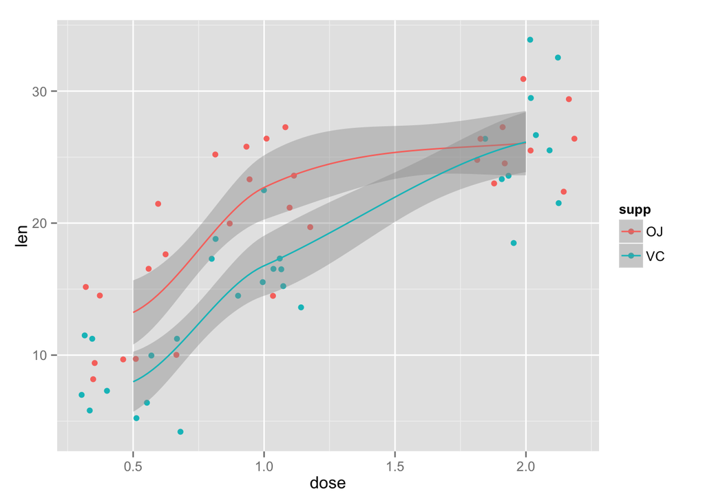

```r
qplot(x = dose, y = len, data = ToothGrowth, geom = c("jitter", "smooth"), color = supp)
```

So now you see what’s going on.

Next, always make a histogram of the DV before making a linear model! This reveals the distribution and can be helpful in choosing your model type.

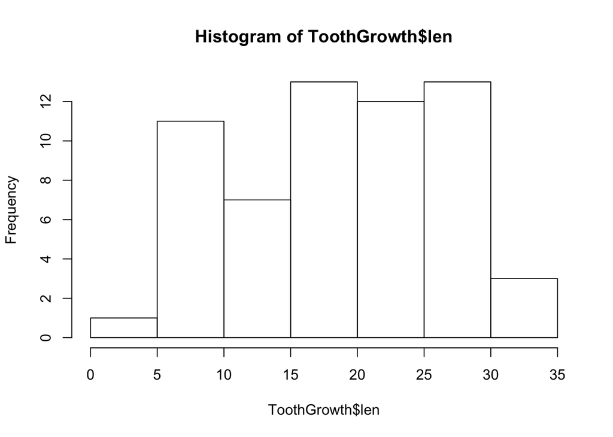

```r
hist(ToothGrowth$len)
```

Now make a linear model of tooth lengths using `lm`. Try making one with main effects and interactions and another with just main effects. Make sure to assign them to variables so that you can get them later.

```r
rs_main_effects <- lm(len ~ dose + supp, ToothGrowth)
summary(rs_main_effects)
```

```
##
## Call:
## lm(formula = len ~ dose + supp, data = ToothGrowth)
##
## Residuals:
##    Min     1Q Median     3Q    Max
## -6.600 -3.700  0.373  2.116  8.800
##
## Coefficients:
##             Estimate Std. Error t value Pr(>|t|)
## (Intercept)   9.2725     1.2824   7.231 1.31e-09 ***
## dose          9.7636     0.8768  11.135 6.31e-16 ***
## suppVC       -3.7000     1.0936  -3.383   0.0013 **
## ---
## Signif. codes:  0 '***' 0.001 '**' 0.01 '*' 0.05 '.' 0.1 ' ' 1
##
## Residual standard error: 4.236 on 57 degrees of freedom
## Multiple R-squared:  0.7038, Adjusted R-squared:  0.6934
## F-statistic: 67.72 on 2 and 57 DF,  p-value: 8.716e-16
```

```r
rs_interaction <- lm(len ~ dose * supp, ToothGrowth)
summary(rs_interaction)
```

```
##
## Call:
## lm(formula = len ~ dose * supp, data = ToothGrowth)
##
## Residuals:
##     Min      1Q  Median      3Q     Max
## -8.2264 -2.8462  0.0504  2.2893  7.9386
##
## Coefficients:
##             Estimate Std. Error t value Pr(>|t|)
## (Intercept)   11.550      1.581   7.304 1.09e-09 ***
## dose           7.811      1.195   6.534 2.03e-08 ***
## suppVC        -8.255      2.236  -3.691 0.000507 ***
## dose:suppVC    3.904      1.691   2.309 0.024631 *
## ---
## Signif. codes:  0 '***' 0.001 '**' 0.01 '*' 0.05 '.' 0.1 ' ' 1
##
## Residual standard error: 4.083 on 56 degrees of freedom
## Multiple R-squared:  0.7296, Adjusted R-squared:  0.7151
## F-statistic: 50.36 on 3 and 56 DF,  p-value: 6.521e-16
```

Now try taking out the intercept, using a -1 term in the formula. what does this do?

```r
rs_interaction_no_int <- lm(len ~ dose * supp -1, ToothGrowth)
summary(rs_interaction_no_int)
```

```
##
## Call:
## lm(formula = len ~ dose * supp - 1, data = ToothGrowth)
##
## Residuals:
##     Min      1Q  Median      3Q     Max
## -8.2264 -2.8463  0.0504  2.2893  7.9386
##
## Coefficients:
##             Estimate Std. Error t value Pr(>|t|)
## dose           7.811      1.195   6.534 2.03e-08 ***
## suppOJ        11.550      1.581   7.304 1.09e-09 ***
## suppVC         3.295      1.581   2.084   0.0418 *
## dose:suppVC    3.904      1.691   2.309   0.0246 *
## ---
## Signif. codes:  0 '***' 0.001 '**' 0.01 '*' 0.05 '.' 0.1 ' ' 1
##
## Residual standard error: 4.083 on 56 degrees of freedom
## Multiple R-squared:  0.9622, Adjusted R-squared:  0.9595
## F-statistic: 356.2 on 4 and 56 DF,  p-value: < 2.2e-16
```

Thought question: Take a moment to interpret the coefficients of the model. Q1 - What are the units? The units of the coefficients are arbitrary. Since dose is quantitative, the coefficient represents the difference in the predicted value of the DV for each one-unit difference, if delivery method remains constants. Since delivery method is categorical, the coefficient is interpreted as a one unit difference representing a switch from one level to another.

Q2 - How does the interaction relate to the plot? The plot shows that at lower doses, both OJ and VC have a strong positive relationship with tooth length, but at higher doses the relationship is stronger for VC, whereas the slope for OJ flattens out.

Q3 - Should there be an interaction in the model? What does it mean? How important is it? There should be an interaction in the model, as OJ and VC do not appear to affect tooth length identically with increasing doses of vitamin C. This means that when using OJ as your source for vitamin C, at some point increasing your dosage does not boost tooth growth, while using VC continues to have a beneficial impact of dosage on tooth growth. This could be due to limits on absorption of vitamin C from OJ. This interaction is important because if increased tooth growth is needed, VC might be a better option than OJ for doses greater than 2.

Now make predictions from the model you like the best. What should happen with doses of 0, 1.5, 2.5, and 10 under both supplements?

HINT: use the `predict` function …

HINT 2: you will have to make a dataframe to do the prediction with, so use something like `data.frame(dose=...)`.

```r
dose_df <- data.frame(dose = rep(c(0, 1.5, 2.5, 10), 2), supp = c(rep("VC", 4), rep("OJ", 4)))
predicted = predict.lm(rs_interaction, dose_df)
```

Now plot the residuals from the original model. How do they look? HINT: `?resid`

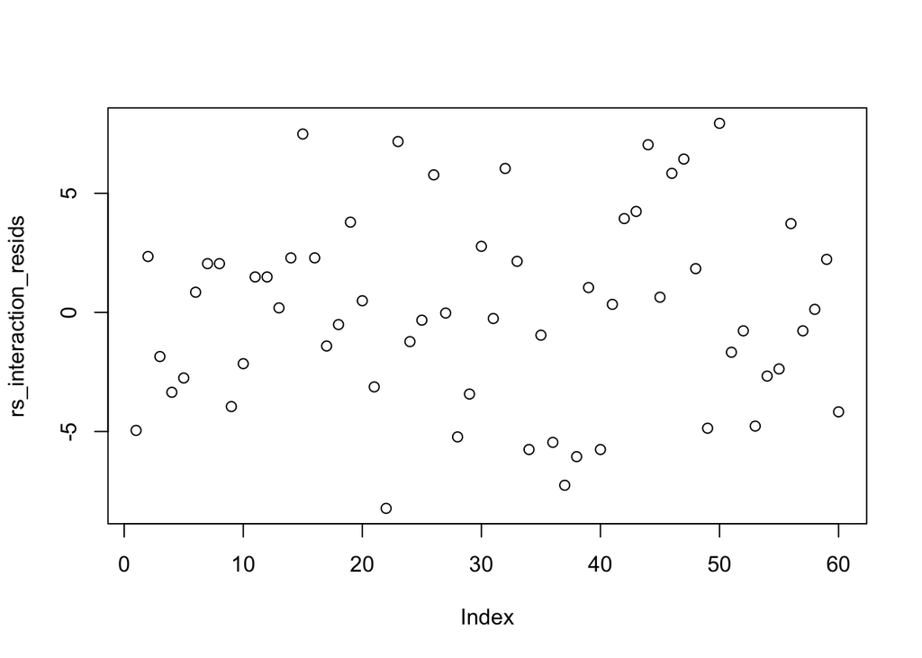

```r
rs_interaction_resids <- resid(rs_interaction)
plot(rs_interaction_resids)
```

There does not appear to be a clear pattern in the residuals, and they appear to be evenly distributed, with no outliers.

BONUS: test them for normality of distribution using a quantile-quantile plot.

HINT: `?qqplot` and `?qqnorm`

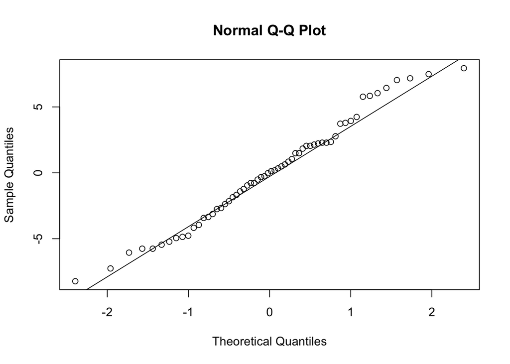

```r
qqnorm(rs_interaction_resids)
qqline(rs_interaction_resids)
```

Deviations from the line are minimal, so it is probably a normal distribution.

## 2B: Exploratory Linear Modeling

What the heck is going on? Load data from Frank, Vul, Saxe (2011, Infancy), a study in which we measured infants’ looking to hands in moving scenes. There were infants from 3 months all the way to about two years, and there were two movie conditions (`Faces_Medium`, in which kids played on a white background, and `Faces_Plus`, in which the backgrounds were more complex and the people in the videos were both kids and adults). Forgive our bad naming conventions.

Try to figure out what the most reasonable linear model of the data is.

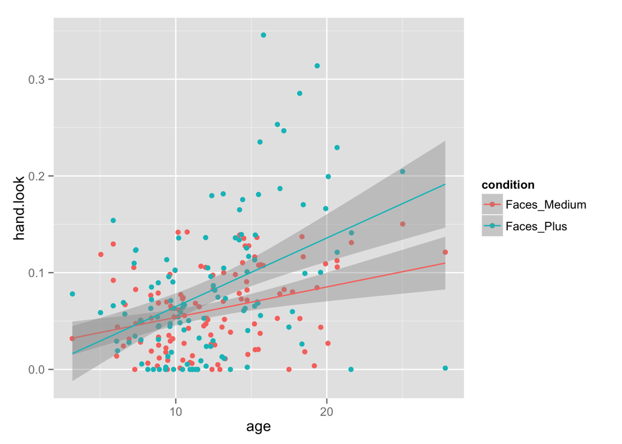

```r
d <- read.csv("../data/FVS2011-hands.csv")
# age, condition (faceplus vs facemed), hand.look

qplot(data = d, x = age, y = hand.look, color = condition, geom = c("jitter", "smooth"), method = "lm") # kids look longer for faces_plus with age
```

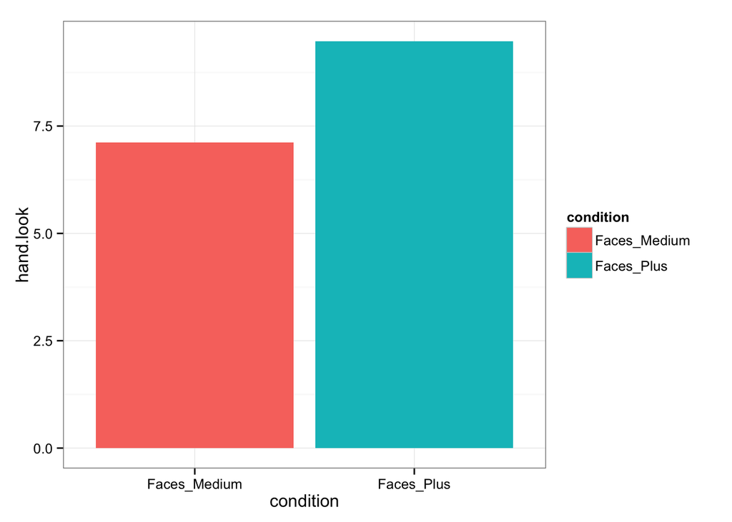

```r
ggplot(d, aes(x = condition, y = hand.look, fill = condition)) + geom_bar(stat="identity") + theme_bw() # look more for faces_plus overall
```

```r
rs1 <- lm(hand.look ~ age, d)
summary(rs1)
```

```
##
## Call:
## lm(formula = hand.look ~ age, data = d)
##
## Residuals:
##       Min        1Q    Median        3Q       Max
## -0.149630 -0.040327 -0.004752  0.027638  0.256434
##
## Coefficients:
##              Estimate Std. Error t value Pr(>|t|)
## (Intercept) 0.0079183  0.0111148   0.712    0.477
## age         0.0051378  0.0008477   6.061  5.5e-09 ***
## ---
## Signif. codes:  0 '***' 0.001 '**' 0.01 '*' 0.05 '.' 0.1 ' ' 1
##
## Residual standard error: 0.05595 on 230 degrees of freedom
## Multiple R-squared:  0.1377, Adjusted R-squared:  0.134
## F-statistic: 36.73 on 1 and 230 DF,  p-value: 5.496e-09
```

```r
rs2 <- lm(hand.look ~ condition, d)
summary(rs2)
```

```
##
## Call:
## lm(formula = hand.look ~ condition, data = d)
##
## Residuals:
##      Min       1Q   Median       3Q      Max
## -0.08169 -0.04172 -0.01124  0.03625  0.26391
##
## Coefficients:
##                     Estimate Std. Error t value Pr(>|t|)
## (Intercept)         0.061309   0.005513  11.121  < 2e-16 ***
## conditionFaces_Plus 0.020377   0.007796   2.614  0.00955 **
## ---
## Signif. codes:  0 '***' 0.001 '**' 0.01 '*' 0.05 '.' 0.1 ' ' 1
##
## Residual standard error: 0.05938 on 230 degrees of freedom
## Multiple R-squared:  0.02884,    Adjusted R-squared:  0.02462
## F-statistic: 6.831 on 1 and 230 DF,  p-value: 0.009552
```

```r
rs3 <- lm(hand.look ~ age + condition, d)
summary(rs3)
```

```
##
## Call:
## lm(formula = hand.look ~ age + condition, data = d)
##
## Residuals:
##       Min        1Q    Median        3Q       Max
## -0.159908 -0.035120 -0.006159  0.028734  0.246199
##
## Coefficients:
##                       Estimate Std. Error t value Pr(>|t|)
## (Intercept)         -0.0023491  0.0115374  -0.204  0.83884
## age                  0.0051414  0.0008351   6.156  3.3e-09 ***
## conditionFaces_Plus  0.0204451  0.0072375   2.825  0.00515 **
## ---
## Signif. codes:  0 '***' 0.001 '**' 0.01 '*' 0.05 '.' 0.1 ' ' 1
##
## Residual standard error: 0.05512 on 229 degrees of freedom
## Multiple R-squared:  0.1667, Adjusted R-squared:  0.1595
## F-statistic: 22.91 on 2 and 229 DF,  p-value: 8.488e-10
```

```r
comp_rs <- anova(rs1, rs3); comp_rs # additive model signif better
```

```
## Analysis of Variance Table
##
## Model 1: hand.look ~ age
## Model 2: hand.look ~ age + condition
##   Res.Df     RSS Df Sum of Sq    F   Pr(>F)
## 1    230 0.71997
## 2    229 0.69573  1  0.024244 7.98 0.005147 **
## ---
## Signif. codes:  0 '***' 0.001 '**' 0.01 '*' 0.05 '.' 0.1 ' ' 1
```

```r
rs4 <- lm(hand.look ~ age * condition, d)
summary(rs4) # interaction signif
```

```
##
## Call:
## lm(formula = hand.look ~ age * condition, data = d)
##
## Residuals:
##       Min        1Q    Median        3Q       Max
## -0.190121 -0.036508 -0.001239  0.032091  0.239474
##
## Coefficients:
##                          Estimate Std. Error t value Pr(>|t|)
## (Intercept)              0.022394   0.015417   1.453  0.14772
## age                      0.003143   0.001176   2.673  0.00807 **
## conditionFaces_Plus     -0.028440   0.021680  -1.312  0.19089
## age:conditionFaces_Plus  0.003950   0.001653   2.389  0.01770 *
## ---
## Signif. codes:  0 '***' 0.001 '**' 0.01 '*' 0.05 '.' 0.1 ' ' 1
##
## Residual standard error: 0.05456 on 228 degrees of freedom
## Multiple R-squared:  0.1871, Adjusted R-squared:  0.1764
## F-statistic: 17.49 on 3 and 228 DF,  p-value: 2.955e-10
```

```r
comp_interact_rs <- anova(rs3, rs4); comp_interact_rs # interaction signif better
```

```
## Analysis of Variance Table
##
## Model 1: hand.look ~ age + condition
## Model 2: hand.look ~ age * condition
##   Res.Df     RSS Df Sum of Sq      F Pr(>F)
## 1    229 0.69573
## 2    228 0.67874  1  0.016992 5.7079 0.0177 *
## ---
## Signif. codes:  0 '***' 0.001 '**' 0.01 '*' 0.05 '.' 0.1 ' ' 1
```

Plot that model on the same plot as the data.

HINT: you can do this either using `predict` or (if you are feeling confident of your understanding of the models) using the built-in linear models in `ggplot`’s `geom_smooth`.

```
## geom_smooth: method="auto" and size of largest group is <1000, so using loess. Use 'method = x' to change the smoothing method.
```

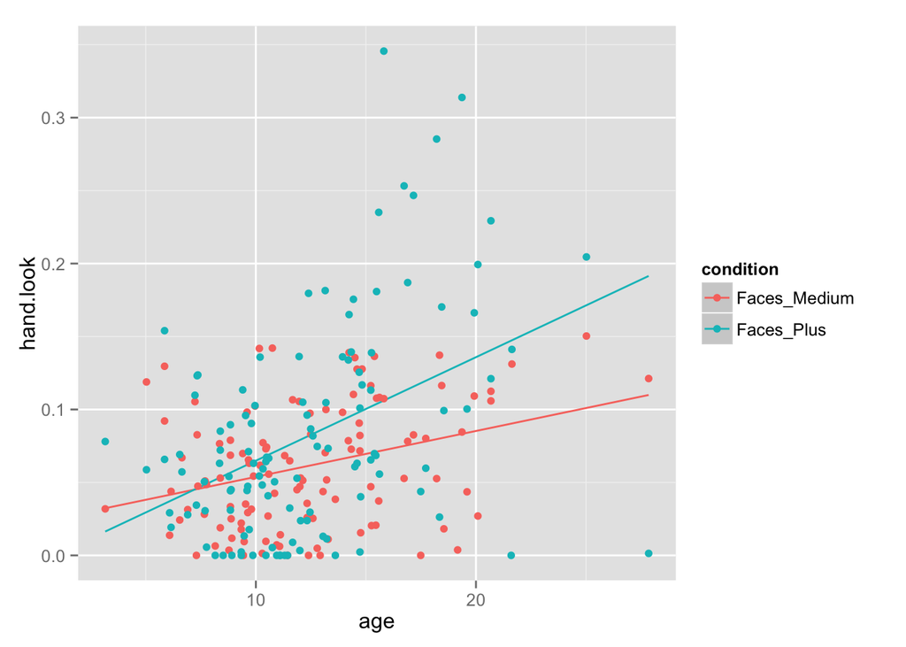

```r
predicted_vals <- predict.lm(rs4)
ggplot(d, aes(x = age, y = hand.look, color = condition)) + geom_smooth(aes(y = predicted_vals)) + geom_point() # aka geom_smooth(method = "lm")
```

What do you conclude from this pattern of data?

From this pattern of data we see that both age and condition predict infants’ looking to hands. Older children tend to look more, and children in the more complex condition tend to look more. There is also an interaction showing that age is more significantly predictive of time looking in the complex condition rather than the normal condition.

# 3: Linear Mixed Effect Models

The goal here is to learn to use LMEMs using `lme4` and to compare them to standard by subject, by item LMs, as well as the standard (no repeated measures) fixed effects GLM.

The dataset here is from Stiller, Goodman, & Frank (2014), a paper on children’s pragmatic inferences. We saw the paradigm in the counterbalancing lecture: it’s three faces: a smiley, a smiley with glasses, and a smiley with a hat and glasses. When told “my friend has glasses” do kids pick the one with the glasses and no hat? `age.group` is the kids’ age group, `condition` is either “label,” described above, or “no label,” which was a control condition in which kids picked without hearing the term “glasses” at all.

```r
library(lme4)
d <- read.csv("/Users/annakhazenzon/Documents/courses/psych254/psych254_materials/data/scales.csv")
d$age.group <- factor(d$age.group)
```

Always begin with a histogram!

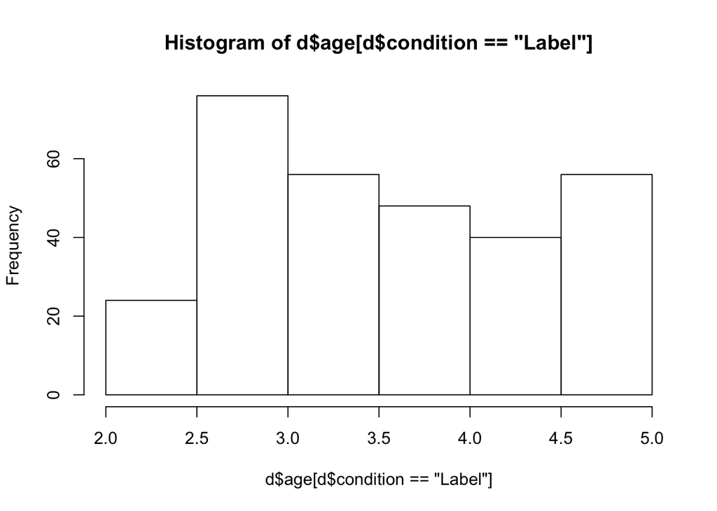

```r
hist(d$age[d$condition == "Label"])
```

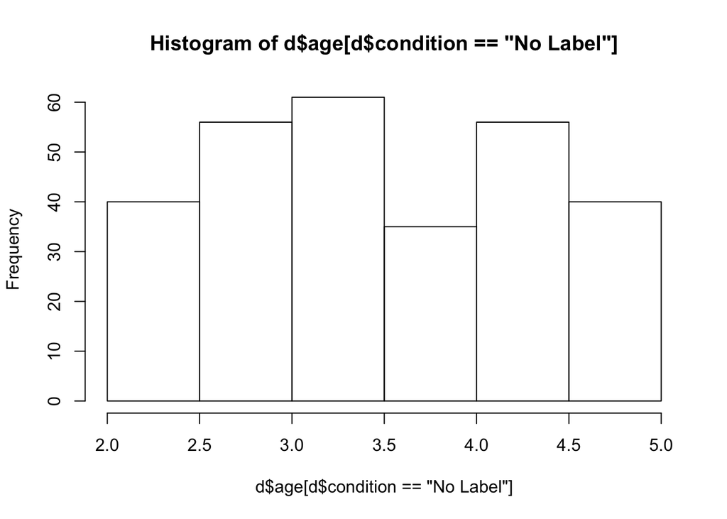

```r
hist(d$age[d$condition == "No Label"])
```

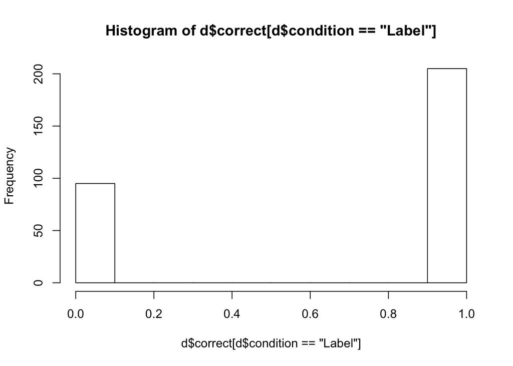

```r
hist(d$correct[d$condition == "Label"])
```

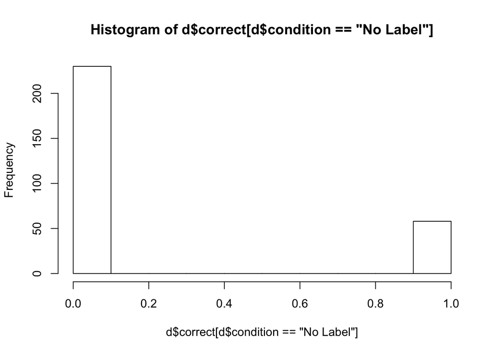

```r
hist(d$correct[d$condition == "No Label"])
```

## Brief Confidence Interval Digression

Start out by setting up a function for a 95% CI using the normal approximation.

```r
# sample statistic +/- margin of error (critical value * sd/se)
sem <- function(x) {sd(x) / sqrt(length(x))}

ci95.norm <- function(x) {
  me <- sem(x) * qnorm(.975)
  c(mean(x) - me, mean(x) + me)
}
```

But the number of participants in a group is likely to be < 30, so let’s also compute this with a t distribution.

```r
ci95.t <- function(x) {
  me <- sem(x) * qt(.975, length(x)-1)
  c(mean(x) - me, mean(x) + me)
}
```

On the other hand, maybe we should use bootstrap CIs because these are actually proportions, and the normal/t approximations don’t know that they are 0/1 bounded.

```r
library(boot)
library(bootstrap)
```

Take a look at `?boot` and `?bootci`. Note that the syntax for the `boot` library is terrible, so we’re going to use it to check some code that I use:

```r
theta <- function(x,xdata,na.rm=T) {mean(xdata[x],na.rm=na.rm)}
ci.low <- function(x,na.rm=T) {
  #mean(x,na.rm=na.rm) -
    quantile(bootstrap(1:length(x),
                       10000,theta,x,na.rm=na.rm)$thetastar,.025,na.rm=na.rm)}
ci.high <- function(x,na.rm=T) {
  quantile(bootstrap(1:length(x),
                     10000,theta,x,na.rm=na.rm)$thetastar,.975,na.rm=na.rm)}
  #- mean(x,na.rm=na.rm)}
```

Now make 95% confidence intervals across participants using all the methods above:

- Normal
- t
- Bootstrap percentile using `boot.ci`
- Bootstrap percentile using my code

```r
ci95.norm(d$correct)
```

```
## [1] 0.4070562 0.4875016
```

```r
ci95.t(d$correct)
```

```
## [1] 0.4069731 0.4875847
```

```r
mean.fun = function(answers, i) {
 mean(answers[i])
}

out <- boot(data = d$correct, statistic = mean.fun, R=999)

boot.ci(out, conf = .95)
```

```
## BOOTSTRAP CONFIDENCE INTERVAL CALCULATIONS
## Based on 999 bootstrap replicates
##
## CALL :
## boot.ci(boot.out = out, conf = 0.95)
##
## Intervals :
## Level      Normal              Basic
## 95%   ( 0.4063,  0.4887 )   ( 0.4082,  0.4898 )
##
## Level     Percentile            BCa
## 95%   ( 0.4048,  0.4864 )   ( 0.4048,  0.4849 )
## Calculations and Intervals on Original Scale
```

```r
ci.low(d$correct)
```

```
##      2.5%
## 0.4081633
```

```r
ci.high(d$correct)
```

```
##     97.5%
## 0.4880952
```

Now plot the data by age and condition using `dplyr` and `ggplot2`. Plot some CIs on here - extra credit if you plot all of them and compare visually (you’ll need `position = position_dodge()` or some other way to offset them).

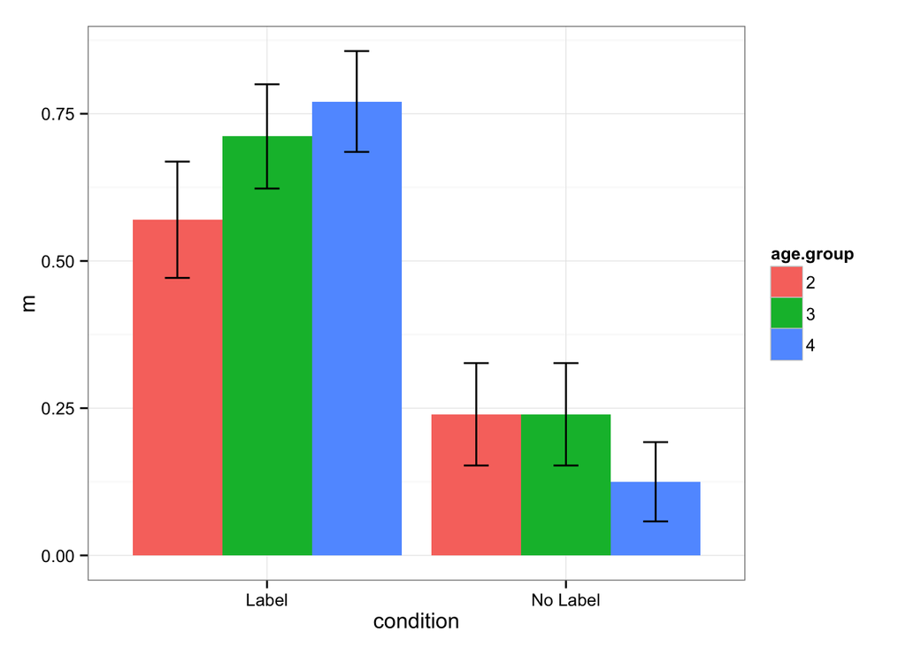

```r
grouped <- d %>% group_by(age.group, condition) %>%
  summarise(m = mean(correct), ci.lo = ci95.t(correct)[1], ci.hi = ci95.t(correct)[2])

limits <- aes(ymax = ci.hi, ymin = ci.lo)

ggplot(grouped, aes(x = condition, y = m, fill = age.group)) + geom_bar(stat="identity", position="dodge") + geom_errorbar(limits, position=position_dodge(width=.9), width=0.25) + theme_bw()
```

What do you conclude about confidence interval computation?

For a fairly large n, using the normal approximation, t approximation, and bootstrapping yields similar confidence intervals.

## Back to LMEMs

```r
library(lme4)
```

OK, now do a basic GLM over the entire data frame, using `age.group`, `condition`, and their interaction to predict correctness. (If we were focusing on developmental issues, I would ask you to think about how to model age here, but let’s treat it as three discrete groups for now).

NOTE: this model is not appropriate, because it assumes that each subject’s observations are independent from one another. It’s still fine to do the analysis, though: it can tell you a lot about the data and is easy and fast to fit, as long as you know that you can’t trust the p-values!

```r
rs <- glm(correct ~ age.group * condition, d, family = "binomial")
summary(rs)
```

```
##
## Call:
## glm(formula = correct ~ age.group * condition, family = "binomial",
##     data = d)
##
## Deviance Residuals:
##     Min       1Q   Median       3Q      Max
## -1.7166  -0.7401  -0.5168   0.8250   2.0393
##
## Coefficients:
##                              Estimate Std. Error z value Pr(>|z|)
## (Intercept)                    0.2819     0.2020   1.395 0.162902
## age.group3                     0.6210     0.2961   2.098 0.035935 *
## age.group4                     0.9312     0.3159   2.948 0.003198 **
## conditionNo Label             -1.4368     0.3130  -4.590 4.43e-06 ***
## age.group3:conditionNo Label  -0.6210     0.4494  -1.382 0.167050
## age.group4:conditionNo Label  -1.7221     0.5022  -3.429 0.000605 ***
## ---
## Signif. codes:  0 '***' 0.001 '**' 0.01 '*' 0.05 '.' 0.1 ' ' 1
##
## (Dispersion parameter for binomial family taken to be 1)
##
##     Null deviance: 808.59  on 587  degrees of freedom
## Residual deviance: 648.74  on 582  degrees of freedom
## AIC: 660.74
##
## Number of Fisher Scoring iterations: 4
```

Let’s now use `dplyr` to get data frames for by-items (`msi`) and by-subjects (`mss`) analyses. `msi` should contain the mean ratings for every item and `mss` should contain the mean ratings for every subject.

```r
msi <- d %>%
  group_by(trial, condition) %>%
  summarise(m = mean(correct))

mss <- d %>%
  group_by(subid) %>%
  summarise(m = mean(correct)) %>%
  inner_join(d[,c("subid", "age.group")], by = "subid")
```

Now do standard linear models on each of these.

NOTE: These are not strictly correct either because of the normal approximation on percent correct (model doesn’t know it’s 0 - 1 bounded and could give you standard error that goes above 1). Again, useful to do and see what happens.

```r
rs1 <- lm(m ~ trial + condition, msi)
summary(rs1)
```

```
##
## Call:
## lm(formula = m ~ trial + condition, data = msi)
##
## Residuals:
##          1          2          3          4          5          6
##  0.0548611 -0.0548611 -0.0045833  0.0045833 -0.0509722  0.0509722
##          7          8
##  0.0006944 -0.0006944
##
## Coefficients:
##                   Estimate Std. Error t value Pr(>|t|)
## (Intercept)        0.74514    0.04843  15.386 0.000596 ***
## trialfaces        -0.08722    0.06126  -1.424 0.249698
## trialhouses       -0.14750    0.06126  -2.408 0.095211 .
## trialpasta        -0.01250    0.06126  -0.204 0.851377
## conditionNo Label -0.48194    0.04332 -11.126 0.001556 **
## ---
## Signif. codes:  0 '***' 0.001 '**' 0.01 '*' 0.05 '.' 0.1 ' ' 1
##
## Residual standard error: 0.06126 on 3 degrees of freedom
## Multiple R-squared:  0.9777, Adjusted R-squared:  0.9479
## F-statistic: 32.84 on 4 and 3 DF,  p-value: 0.008228
```

```r
rs2 <- lm(m ~ as.numeric(subid) + age.group, mss) # subject ID is not a meaningful var
summary(rs2)
```

```
##
## Call:
## lm(formula = m ~ as.numeric(subid) + age.group, data = mss)
##
## Residuals:
##      Min       1Q   Median       3Q      Max
## -0.51840 -0.26187 -0.04822  0.22950  0.78181
##
## Coefficients:
##                     Estimate Std. Error t value Pr(>|t|)
## (Intercept)        0.7108391  0.0361267  19.676   <2e-16 ***
## as.numeric(subid) -0.0032617  0.0003113 -10.479   <2e-16 ***
## age.group3        -0.0229591  0.0319844  -0.718    0.473
## age.group4        -0.0440463  0.0318667  -1.382    0.167
## ---
## Signif. codes:  0 '***' 0.001 '**' 0.01 '*' 0.05 '.' 0.1 ' ' 1
##
## Residual standard error: 0.3038 on 584 degrees of freedom
## Multiple R-squared:  0.1659, Adjusted R-squared:  0.1616
## F-statistic: 38.71 on 3 and 584 DF,  p-value: < 2.2e-16
```

Do ANOVA on these. Note that ANOVA doesn’t let you figure out what is going on with individual levels of age.

```r
rs1 <- aov(m ~ trial + condition, msi)
summary(rs1)
```

```
##             Df Sum Sq Mean Sq F value  Pr(>F)
## trial        3 0.0285  0.0095    2.53 0.23300
## condition    1 0.4645  0.4645  123.78 0.00156 **
## Residuals    3 0.0113  0.0038
## ---
## Signif. codes:  0 '***' 0.001 '**' 0.01 '*' 0.05 '.' 0.1 ' ' 1
```

```r
rs2 <- aov(m ~ subid + age.group, mss)
summary(rs2)
```

```
##              Df Sum Sq Mean Sq   F value Pr(>F)
## subid       146  64.62  0.4426 2.371e+27 <2e-16 ***
## Residuals   441   0.00  0.0000
## ---
## Signif. codes:  0 '***' 0.001 '**' 0.01 '*' 0.05 '.' 0.1 ' ' 1
```

On to linear mixed effect models. Create the maximal random effects model a la Barr et al. (2013). Does it converge? If not, what will you do to make it converge? (The internet can be your friend here).

HINT: try simplifying your model to a “semi-maximal” model. Bonus: try using a different fitting procedure on the maximal model.

HINT: make sure that you consider which random effects are appropriate. Consider which observations are within/between subjects. E.g. having a random coefficient for age by subject doesn’t make sense, because each subject has only one age.

```r
#max_rs <- glmer(correct ~ subid * age.group * trial * condition * (condition + trial + age.group | subid), d, family = "binomial")
# error: number of obs is less than the number of random effects

submax_rs <- glmer(correct ~ age.group + trial + condition + (trial | subid), d, family = "binomial")
summary(submax_rs)
```

```
## Generalized linear mixed model fit by maximum likelihood (Laplace
##   Approximation) [glmerMod]
##  Family: binomial  ( logit )
## Formula: correct ~ age.group + trial + condition + (trial | subid)
##    Data: d
##
##      AIC      BIC   logLik deviance df.resid
##    678.8    753.2   -322.4    644.8      571
##
## Scaled residuals:
##     Min      1Q  Median      3Q     Max
## -2.0281 -0.5172 -0.3193  0.5888  2.4919
##
## Random effects:
##  Groups Name        Variance Std.Dev. Corr
##  subid  (Intercept) 0.1370   0.3701
##         trialfaces  0.5155   0.7180   -0.06
##         trialhouses 1.3650   1.1683   -0.51  0.84
##         trialpasta  1.1546   1.0745   -0.80  0.65  0.91
## Number of obs: 588, groups:  subid, 147
##
## Fixed effects:
##                   Estimate Std. Error z value Pr(>|z|)
## (Intercept)         1.0419     0.2749   3.790  0.00015 ***
## age.group3          0.4314     0.2730   1.580  0.11404
## age.group4          0.2777     0.2780   0.999  0.31779
## trialfaces         -0.5220     0.2920  -1.787  0.07387 .
## trialhouses        -0.9298     0.3053  -3.045  0.00233 **
## trialpasta         -0.0797     0.2970  -0.268  0.78841
## conditionNo Label  -2.5076     0.2067 -12.133  < 2e-16 ***
## ---
## Signif. codes:  0 '***' 0.001 '**' 0.01 '*' 0.05 '.' 0.1 ' ' 1
##
## Correlation of Fixed Effects:
##             (Intr) ag.gr3 ag.gr4 trlfcs trlhss trlpst
## age.group3  -0.488
## age.group4  -0.492  0.501
## trialfaces  -0.515 -0.016  0.000
## trialhouses -0.485  0.012  0.016  0.492
## trialpasta  -0.521 -0.005  0.007  0.499  0.526
## conditnNLbl -0.361 -0.032 -0.019  0.064 -0.041  0.022
```

```r
indep_coeff_rs <- glm(correct ~ age.group + condition + trial, d, family = "binomial")
summary(indep_coeff_rs)
```

```
##
## Call:
## glm(formula = correct ~ age.group + condition + trial, family = "binomial",
##     data = d)
##
## Deviance Residuals:
##     Min       1Q   Median       3Q      Max
## -1.7597  -0.7762  -0.5391   0.8492   2.1042
##
## Coefficients:
##                   Estimate Std. Error z value Pr(>|z|)
## (Intercept)        0.91908    0.25056   3.668 0.000244 ***
## age.group3         0.39010    0.23463   1.663 0.096381 .
## age.group4         0.24279    0.23723   1.023 0.306095
## conditionNo Label -2.20729    0.19735 -11.185  < 2e-16 ***
## trialfaces        -0.47482    0.27158  -1.748 0.080397 .
## trialhouses       -0.80999    0.27504  -2.945 0.003230 **
## trialpasta        -0.07289    0.27002  -0.270 0.787192
## ---
## Signif. codes:  0 '***' 0.001 '**' 0.01 '*' 0.05 '.' 0.1 ' ' 1
##
## (Dispersion parameter for binomial family taken to be 1)
##
##     Null deviance: 808.59  on 587  degrees of freedom
## Residual deviance: 649.69  on 581  degrees of freedom
## AIC: 663.69
##
## Number of Fisher Scoring iterations: 4
```

How do these coefficients compare with the independent coefficients linear model? What do you conclude?

The coefficients do not differ greatly between the two models. The random effects of item type must not explain much of the variance.

Which random effects make the most difference? Find out using `ranef`. Plot the random effects for subject and item.

```r
diag(var(ranef(submax_rs)$subid[1:4]))
```

```
## (Intercept)  trialfaces trialhouses  trialpasta
##  0.01146951  0.11905132  0.30690550  0.20038674
```

```
## Plotting random effects...
```

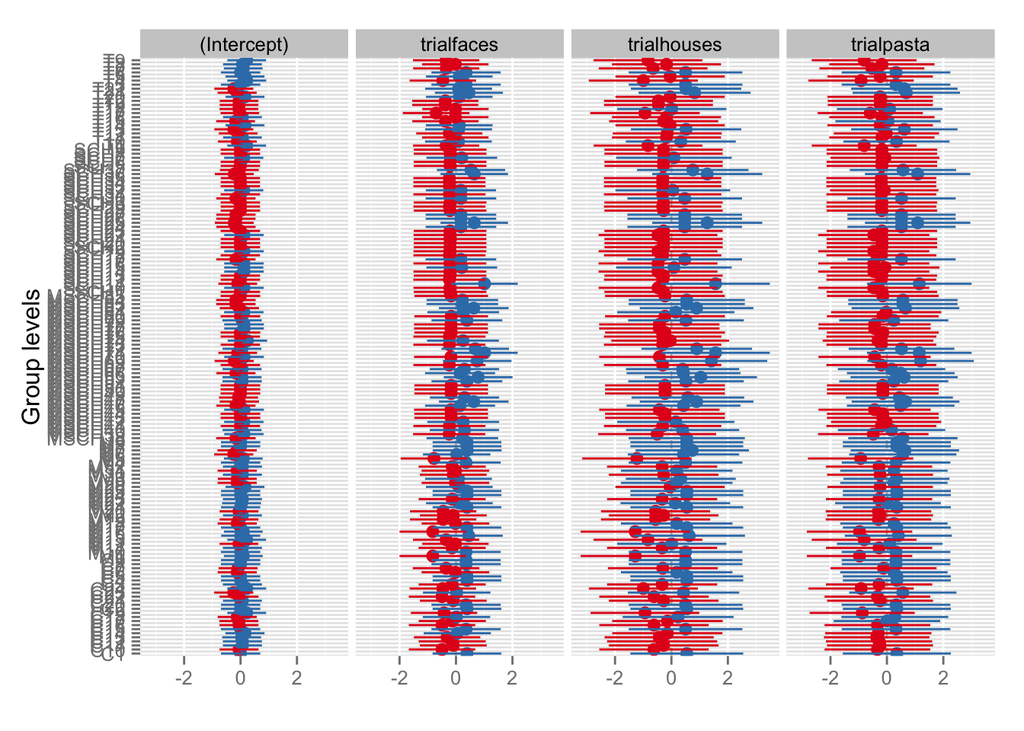

```r
library(sjPlot)
sjp.lmer(submax_rs)
```

House items appear to have the largest random slope.

Make the minimal random effects model with just a subject intecept. How does this compare?

```r
min_rs <- glmer(correct ~ 1 + (1 | subid), d, family = "binomial")
summary(min_rs)
```

```
## Generalized linear mixed model fit by maximum likelihood (Laplace
##   Approximation) [glmerMod]
##  Family: binomial  ( logit )
## Formula: correct ~ 1 + (1 | subid)
##    Data: d
##
##      AIC      BIC   logLik deviance df.resid
##    771.5    780.3   -383.8    767.5      586
##
## Scaled residuals:
##     Min      1Q  Median      3Q     Max
## -1.2888 -0.6906 -0.4812  0.7760  1.4480
##
## Random effects:
##  Groups Name        Variance Std.Dev.
##  subid  (Intercept) 1.569    1.253
## Number of obs: 588, groups:  subid, 147
##
## Fixed effects:
##             Estimate Std. Error z value Pr(>|z|)
## (Intercept)  -0.2825     0.1417  -1.994   0.0462 *
## ---
## Signif. codes:  0 '***' 0.001 '**' 0.01 '*' 0.05 '.' 0.1 ' ' 1
```

```r
sjp.lmer(min_rs)
```

```
## Plotting random effects...
```

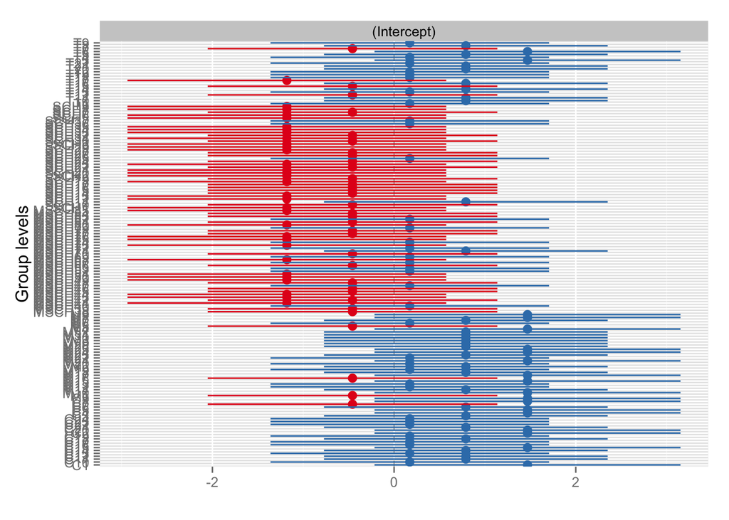

The random effects of subject ID explain a lot more of the variance now that there are no other predictors in the model.

Get an estimate of the significance value for the coefficient on the `age*condition` interaction by using anova to compare between your semi-maximal model and the model without an intercept.

```r
semi_max_intrxn <- glmer(correct ~ trial + age * condition + (1 | subid), d, family = "binomial")
summary(semi_max_intrxn)
```

```
## Generalized linear mixed model fit by maximum likelihood (Laplace
##   Approximation) [glmerMod]
##  Family: binomial  ( logit )
## Formula: correct ~ trial + age * condition + (1 | subid)
##    Data: d
##
##      AIC      BIC   logLik deviance df.resid
##    653.0    688.0   -318.5    637.0      580
##
## Scaled residuals:
##     Min      1Q  Median      3Q     Max
## -2.5844 -0.5803 -0.3525  0.6395  2.6646
##
## Random effects:
##  Groups Name        Variance Std.Dev.
##  subid  (Intercept) 0.05995  0.2449
## Number of obs: 588, groups:  subid, 147
##
## Fixed effects:
##                       Estimate Std. Error z value Pr(>|z|)
## (Intercept)           -0.78556    0.62837  -1.250 0.211244
## trialfaces            -0.48969    0.27657  -1.771 0.076629 .
## trialhouses           -0.83830    0.28163  -2.977 0.002914 **
## trialpasta            -0.07412    0.27407  -0.270 0.786834
## age                    0.55238    0.17295   3.194 0.001404 **
## conditionNo Label      0.99982    0.89167   1.121 0.262164
## age:conditionNo Label -0.93141    0.25836  -3.605 0.000312 ***
## ---
## Signif. codes:  0 '***' 0.001 '**' 0.01 '*' 0.05 '.' 0.1 ' ' 1
##
## Correlation of Fixed Effects:
##             (Intr) trlfcs trlhss trlpst age    cndtNL
## trialfaces  -0.208
## trialhouses -0.191  0.499
## trialpasta  -0.218  0.497  0.489
## age         -0.934 -0.026 -0.051 -0.003
## conditnNLbl -0.658 -0.004 -0.011  0.001  0.664
## ag:cndtnNLb  0.626  0.028  0.050  0.003 -0.676 -0.969
```

```r
no_int_intrxn <- glmer(correct ~ -1 + trial + age * condition + (1 | subid), d, family = "binomial")
summary(no_int_intrxn)
```

```
## Generalized linear mixed model fit by maximum likelihood (Laplace
##   Approximation) [glmerMod]
##  Family: binomial  ( logit )
## Formula: correct ~ -1 + trial + age * condition + (1 | subid)
##    Data: d
##
##      AIC      BIC   logLik deviance df.resid
##    653.0    688.0   -318.5    637.0      580
##
## Scaled residuals:
##     Min      1Q  Median      3Q     Max
## -2.5844 -0.5804 -0.3525  0.6396  2.6646
##
## Random effects:
##  Groups Name        Variance Std.Dev.
##  subid  (Intercept) 0.05999  0.2449
## Number of obs: 588, groups:  subid, 147
##
## Fixed effects:
##                       Estimate Std. Error z value Pr(>|z|)
## trialbeds              -0.7858     0.6283  -1.251 0.211070
## trialfaces             -1.2754     0.6316  -2.019 0.043445 *
## trialhouses            -1.6241     0.6375  -2.548 0.010841 *
## trialpasta             -0.8598     0.6285  -1.368 0.171295
## age                     0.5524     0.1729   3.194 0.001401 **
## conditionNo Label       0.9999     0.8916   1.122 0.262066
## age:conditionNo Label  -0.9314     0.2583  -3.606 0.000312 ***
## ---
## Signif. codes:  0 '***' 0.001 '**' 0.01 '*' 0.05 '.' 0.1 ' ' 1
##
## Correlation of Fixed Effects:
##             trlbds trlfcs trlhss trlpst age    cndtNL
## trialfaces   0.904
## trialhouses  0.901  0.903
## trialpasta   0.905  0.904  0.902
## age         -0.934 -0.941 -0.944 -0.935
## conditnNLbl -0.658 -0.656 -0.653 -0.657  0.663
## ag:cndtnNLb  0.626  0.635  0.639  0.627 -0.676 -0.969
```

```r
anova(semi_max_intrxn, no_int_intrxn)
```

```
## Data: d
## Models:
## semi_max_intrxn: correct ~ trial + age * condition + (1 | subid)
## no_int_intrxn: correct ~ -1 + trial + age * condition + (1 | subid)
##                 Df    AIC    BIC  logLik deviance Chisq Chi Df Pr(>Chisq)
## semi_max_intrxn  8 652.97 687.98 -318.49   636.97
## no_int_intrxn    8 652.97 687.98 -318.49   636.97     0      0  < 2.2e-16
##
## semi_max_intrxn
## no_int_intrxn   ***
## ---
## Signif. codes:  0 '***' 0.001 '**' 0.01 '*' 0.05 '.' 0.1 ' ' 1
```

These models are effectively equivalent, and running an ANOVA to compare models that are not nested leads to uninterpretable results.